# Assignment 4

Author

Nathan Weitershausen

# HPC

```r
library(microbenchmark)
library(ggplot2)

# Use the functions with this data
set.seed(2315)
dat <- matrix(rnorm(200 * 100), nrow = 200)
```

For Questions 1 and 2, rewrite the provided R functions to make them faster. It is OK (and recommended) to take a look at StackOverflow and Google.

Using the synthetic dataset provided, show that your new function returns the same output as the original function. Then use `microbenchmark` to show that your version is faster and provide a visualization of the runtimes.

## Question 1

fun1: Find the total for each row of a numeric matrix. Output should be a vector with length equal to the number of rows of the input matrix.

```r
# Total for each row
fun1 <- function(mat) {
  n <- nrow(mat)
  ans <- double(n)
  for (i in 1:n) {
    ans[i] <- sum(mat[i, ])
  }
  ans
}

fun1alt <- function(mat) {
  rowSums(mat)
}

# Microbenchmark
all.equal(fun1(dat), fun1alt(dat))
```

```
[1] TRUE
```

```r
Runtime <- microbenchmark(fun1(dat), fun1alt(dat))
print(Runtime)
```

```
Unit: microseconds
         expr   min    lq    mean median     uq   max neval
    fun1(dat) 175.4 210.2 224.169  216.8 240.55 377.1   100
 fun1alt(dat)  41.8  42.7  53.063   43.4  44.00 859.5   100
```

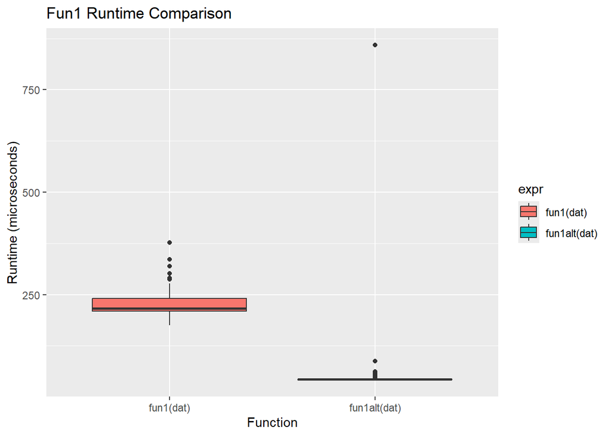

```r
# Visualization
ggplot(Runtime, aes(x=expr, y = time/1000, fill = expr)) + geom_boxplot() + labs(title="Fun1 Runtime Comparison", x = "Function", y = "Runtime (microseconds)")
```

### Summary

The table reveals that fun1 and fun1alt return the same output. The microbenchmark output and the boxplots reveal that fun1alt is faster.

## Question 2

fun2: Calculate the running (cumulative) total along each row of a numeric matrix. Output should be a matrix with dimensions equal to the input matrix.

```r
# running cumulative sum by row
fun2 <- function(mat) {
  n <- nrow(mat)
  k <- ncol(mat)
  ans <- mat
  for (i in 1:n) {
    for (j in 2:k) {
      ans[i,j] <- mat[i, j] + ans[i, j - 1]
    }
  }
  ans
}

fun2alt <- function(mat) {
  t(apply(mat, 1, cumsum))
}

# Microbenchmark
all.equal(fun2(dat), fun2alt(dat))
```

```
[1] TRUE
```

```r
Runtime2 <- microbenchmark(fun2(dat), fun2alt(dat))
print(Runtime2)
```

```
Unit: microseconds
         expr    min      lq     mean median     uq    max neval
    fun2(dat) 1391.1 1421.05 1538.138 1454.5 1492.4 2703.0   100
 fun2alt(dat)  409.7  451.40  664.388  526.6  684.9 4455.4   100
```

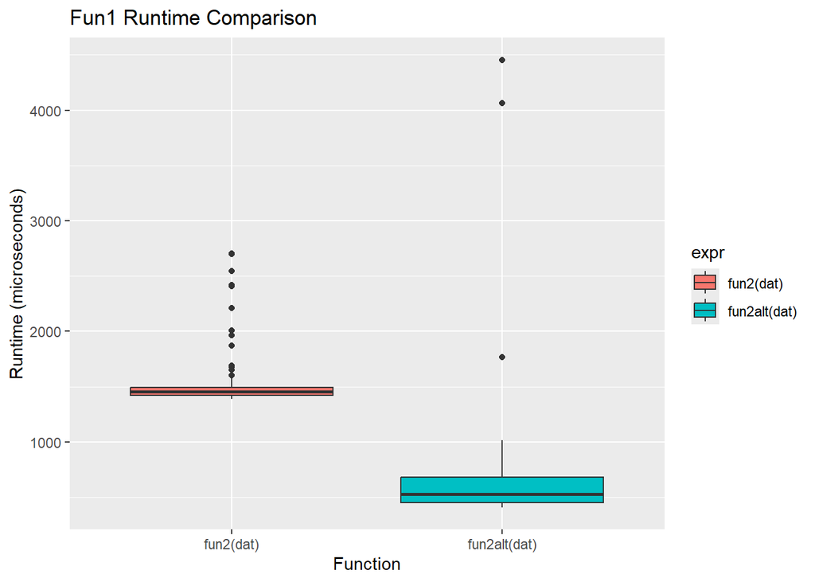

```r
# Visualization
ggplot(Runtime2, aes(x=expr, y = time/1000, fill = expr)) + geom_boxplot() + labs(title="Fun1 Runtime Comparison", x = "Function", y = "Runtime (microseconds)")
```

### Summary

The table reveals that fun2 and fun2alt return the same output. The microbenchmark output and the boxplots reveal that fun2alt is faster.

## Question 3

For this question, we will ask you to parallelize a process for computationally estimating the value of pi.

The following function allows us to estimate pi through a simple simulation:

```r
library(parallel)

sim_pi <- function(n = 1000, i = NULL) {
  p <- matrix(runif(n*2), ncol = 2)
  mean(rowSums(p^2) < 1) * 4
}

# Here is an example of the run
set.seed(156)
sim_pi(1000) # 3.132
```

```
[1] 3.132
```

```r
# In order to get more accurate estimates, we can run this function multiple times and take the mean:
# This runs the simulation a 4,000 times, each with 10,000 points
set.seed(1231)
system.time({
  ans <- unlist(lapply(1:4000, sim_pi, n = 10000))
  print(mean(ans))
})
```

```
[1] 3.14124
```

```
   user  system elapsed
   1.21    0.03    1.23
```

Rewrite the previous code using parLapply() (or your parallelization method of choice) to parallelize it. Run the code once, using system.time(), to show that your version is faster.

```r
set.seed(1231)
Original <- system.time({
  ans_original <- unlist(lapply(1:4000, sim_pi, n = 10000))
  print(mean(ans))
})
```

```
[1] 3.14124
```

```r
cl <- makeCluster(2L)
clusterSetRNGStream(cl,iseed = 1231)
Parallel <- system.time({
  ans_parallel <- unlist(parLapply(cl, 1:4000, sim_pi, n = 10000))
  print(mean(ans))
  stopCluster(cl)
})
```

```
[1] 3.14124
```

Visualize your results in two ways:

1. Show that both versions produce similar ranges of estimates for pi.
2. Show that the parallel version runs faster.

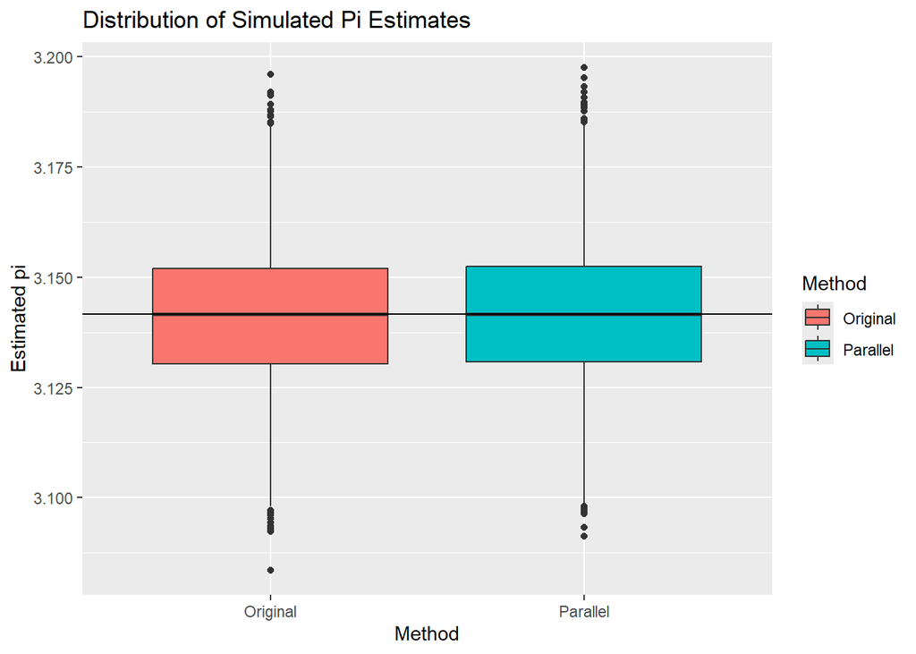

```r
# Show that both versions produce similar ranges of estimates for pi.
Pi_Estimates <- data.frame(Method = rep(c("Original", "Parallel"), c(length(ans_original), length(ans_parallel))), Estimate = c(ans_original, ans_parallel))

ggplot(Pi_Estimates, aes(x= Method, y = Estimate, fill = Method)) + geom_boxplot() + labs(title = "Distribution of Simulated Pi Estimates", y = "Estimated pi") + geom_hline(yintercept = pi)
```

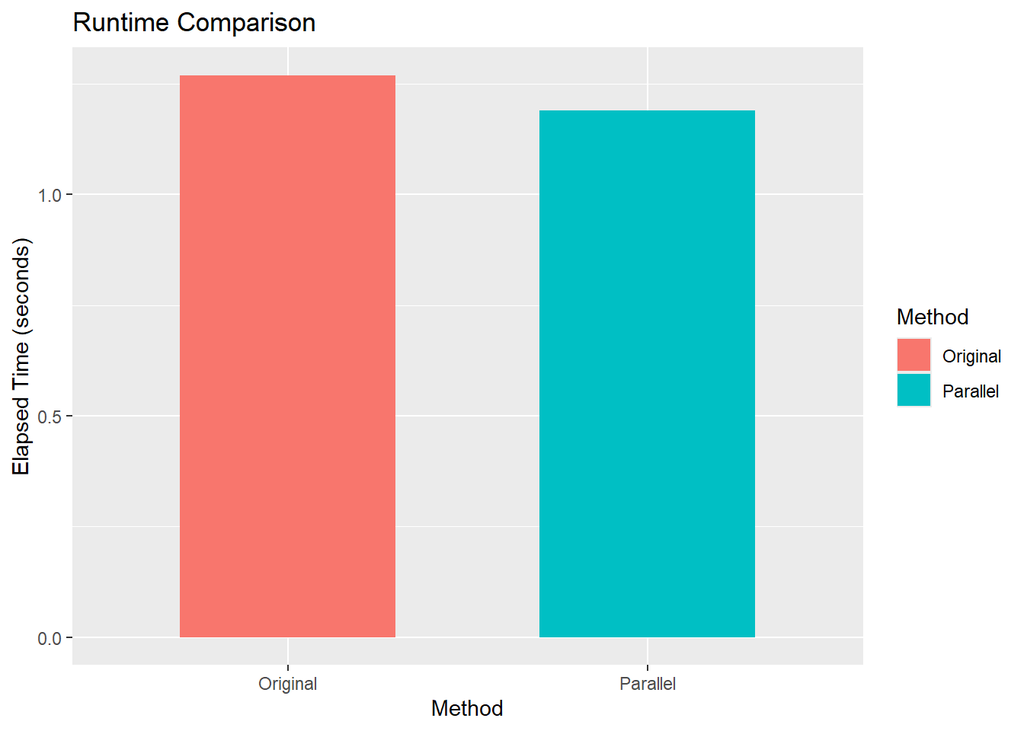

```r
# Show that the parallel version runs faster.
Timing <- data.frame(Method = c("Original", "Parallel"), Seconds = c(Original[["elapsed"]], Parallel[["elapsed"]]))

ggplot(Timing, aes(x=Method, y = Seconds, fill = Method))+ geom_col(width = 0.6) + labs(title = "Runtime Comparison", y = "Elapsed Time (seconds)")
```

### Summary

The boxplot reveals that both versions produce similar ranges of estimates for pi. The barchart reveals that the parallel version runs faster than the original version.

# SQL

Setup a temporary database of movie data by running the following code chunk:

```r
# install.packages(c("RSQLite", "DBI"))

library(RSQLite)
library(DBI)

# Initialize a temporary in memory database
con <- dbConnect(SQLite(), ":memory:")

# Download tables
film <- read.csv("https://raw.githubusercontent.com/ivanceras/sakila/master/csv-sakila-db/film.csv")
film_category <- read.csv("https://raw.githubusercontent.com/ivanceras/sakila/master/csv-sakila-db/film_category.csv")
category <- read.csv("https://raw.githubusercontent.com/ivanceras/sakila/master/csv-sakila-db/category.csv")

# Copy data.frames to database
dbWriteTable(con, "film", film)
dbWriteTable(con, "film_category", film_category)
dbWriteTable(con, "category", category)
```

## Question 4

How many movies are available in each rating category?

```sql
SELECT rating, COUNT(*) AS number_of_movies
FROM film
GROUP BY rating
ORDER BY number_of_movies DESC
```

5 records

| rating | number_of_movies |
| --- | --- |
| PG-13 | 223 |
| NC-17 | 210 |
| R | 195 |
| PG | 194 |
| G | 180 |

### Summary

There are 223 PG-13-rated movies, 210 NC-17-rated movies, 195 R-rated movies, 194 PG-rated movies, and 180 G-rated movies.

## Question 5

What is the average replacement cost and rental rate for each rating category?

```sql
SELECT rating, AVG(replacement_cost) AS avg_replacement_cost, AVG(rental_rate) AS avg_rental_rate
FROM film
GROUP BY rating
ORDER BY rating
```

5 records

| rating | avg_replacement_cost | avg_rental_rate |
| --- | --- | --- |
| G | 20.12333 | 2.912222 |
| NC-17 | 20.13762 | 2.970952 |
| PG | 18.95907 | 3.051856 |
| PG-13 | 20.40256 | 3.034843 |
| R | 20.23103 | 2.938718 |

### Summary

For G-rated movies, the average replacement cost is ~$20.12 and the average rental rate is ~2.91. For NC-17-rated movies, the average replacement cost is ~20.14 and the average rental rate is ~2.97. For PG-rated movies, the average replacement cost is ~$18.96 and the average rental rate is ~3.05. For PG-13-rated movies, the average replacement cost is ~$20.40 and the average rental rate is ~3.03. For R-rated movies, the average replacement cost is ~$20.23 and the average rental rate is ~2.94.

## Question 6

Use table film_category together with film to find how many films there are with each category ID.

```sql
SELECT film_category.category_id, COUNT(*) AS number_of_films
FROM film
INNER JOIN film_category
ON film.film_id = film_category.film_id
GROUP BY film_category.category_id
ORDER BY film_category.category_id
```

Displaying records 1 - 10

| category_id | number_of_films |
| --- | --- |
| 1 | 64 |
| 2 | 66 |
| 3 | 60 |
| 4 | 57 |
| 5 | 58 |
| 6 | 68 |
| 7 | 62 |
| 8 | 69 |
| 9 | 73 |
| 10 | 61 |

## Question 7

Incorporate the category table into the answer to the previous question to find the name of the most popular category.

```sql
SELECT category.name, COUNT(*) AS number_of_films
FROM film
INNER JOIN film_category
ON film.film_id = film_category.film_id
INNER JOIN category
ON film_category.category_id = category.category_id
GROUP BY category.category_id, category.name
ORDER BY number_of_films DESC
```

Displaying records 1 - 10

| name | number_of_films |
| --- | --- |
| Sports | 74 |
| Foreign | 73 |
| Family | 69 |
| Documentary | 68 |
| Animation | 66 |
| Action | 64 |
| New | 63 |
| Drama | 62 |
| Games | 61 |
| Sci-Fi | 61 |

### Summary

The most popular film category is “Sports,” with 74 films.

```r
dbDisconnect(con)
```